# Tidyr unite and pivot_wider Functions

# I. Overlooked Tidyr Functions

## Purpose

I would like to demonstrate two overlooked functions of tidyr, **unite** and **pivot_wider**.

The solutions may not be the best fit for the question that will be proposed, but the main idea is to give you more ideas on how to model your data.

## The Data

We will be using a Netflix dataset found from Kaggle located at https://www.kaggle.com/shivamb/netflix-shows#netflix_titles.csv.

|  | title | type | rating |
| --- | --- | --- | --- |
| 1 | Norm of the North: King Sized Adventure | Movie | TV-PG |
| 2 | Jandino: Whatever it Takes | Movie | TV-MA |
| 3 | Transformers Prime | TV Show | TV-Y7-FV |
| 4 | Transformers: Robots in Disguise | TV Show | TV-Y7 |
| 5 | #realityhigh | Movie | TV-14 |
| 6 | Apaches | TV Show | TV-MA |
| 7 | Automata | Movie | R |
| 8 | Fabrizio Copano: Solo pienso en mi | Movie | TV-MA |
| 9 | Fire Chasers | TV Show | TV-MA |
| 10 | Good People | Movie | R |

[output cut: 6224 more lines]

# II. Question and Answer

## Question

Let’s say I’d like to use this data to find appropriate movies for my wife and daughter to watch with me, what are ways this data could be presented to make finding these type of movies easier?

## Answer Using “unite”

**unite** is a great function that gives you the ability to bring together several columns into one.

The function name “unite” is also very intuitive and greatly increases the readability of your code.

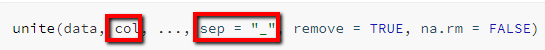

1. The first step is to use the **col** argument to give a new name to the column you will create.
2. Next, use the **…** argument which represents all the columns that will be united, comma separated.
3. Finally, the **sep** argument is used to add a text separator between the values you will unite.

Now we will **unite** the *type* and *rating* column into one.

Below is an example using the function:

```r
netflix <- unite(data = netflix_before,
                  col = "Type",        #Name of new column
                  type, rating,        #Columns being united
                  sep = ", Rated ")    #Text to put in between columns

datatable(netflix)
```

|  | title | Type |
| --- | --- | --- |
| 1 | Norm of the North: King Sized Adventure | Movie, Rated TV-PG |
| 2 | Jandino: Whatever it Takes | Movie, Rated TV-MA |
| 3 | Transformers Prime | TV Show, Rated TV-Y7-FV |
| 4 | Transformers: Robots in Disguise | TV Show, Rated TV-Y7 |
| 5 | #realityhigh | Movie, Rated TV-14 |
| 6 | Apaches | TV Show, Rated TV-MA |
| 7 | Automata | Movie, Rated R |
| 8 | Fabrizio Copano: Solo pienso en mi | Movie, Rated TV-MA |
| 9 | Fire Chasers | TV Show, Rated TV-MA |
| 10 | Good People | Movie, Rated R |

[output cut: 6224 more lines]

## Alternative Answer Using “pivot_wider”

This tidyr function is notoriously confusing but I wanted to include this in hopes of dispelling it’s bad rep!

First let’s look at the signature:

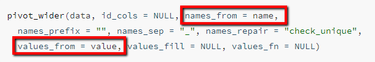

For pivot_wider you want to look carefully at an observation and think, **"what two values can I turn into a column - value pair?**

1. *names_from* will be your column values
2. *values_from* will continue to be your values, but spread into columns assigned from #1

In the picture below you can see we are taking *rating* as the **names_from** value, to turn it into columns.

Next, we take the *listed_in* column as the **values_from** value, which will will be mapped as the values to the columns we created.

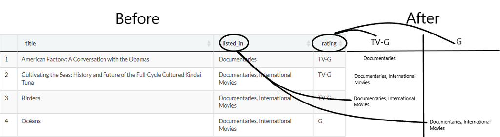

### Before pivot_wider

Here is what the data looks like before applying **pivot_wider**

|  | title | listed_in | rating |
| --- | --- | --- | --- |
| 1 | American Factory: A Conversation with the Obamas | Documentaries | TV-G |
| 2 | Cultivating the Seas: History and Future of the Full-Cycle Cultured Kindai Tuna | Documentaries, International Movies | TV-G |
| 3 | Birders | Documentaries, International Movies | TV-G |
| 4 | Océans | Documentaries, International Movies | G |
| 5 | Barbie Dolphin Magic | Children &amp; Family Movies | TV-G |
| 6 | Ghost of the Mountains | Documentaries | G |
| 7 | Spookley the Square Pumpkin | Children &amp; Family Movies | G |
| 8 | High Risk | Docuseries, Reality TV | TV-G |
| 9 | Siddhant | Dramas, Independent Movies, International Movies | TV-G |
| 10 | Benji's Very Own Christmas Story | Children &amp; Family Movies | TV-G |

[output cut: 176 more lines]

### Applying pivot_wider

We will take the “rating” columns and pass it to the **names_from** argument to turn it into columns. Then we will take the “listed_in” column and pass it to the **values_from** argument so that the values will be mapped to the new columns generated from “rating”

```r
datatable(pivot_wider(after,
                      names_from = rating,       #COLUMNS (KEY)
                      values_from = listed_in),  #VALUES (Will map to KEY)
          options = list(pageLength = 4))
```

|  | title | TV-G | G |
| --- | --- | --- | --- |
| 1 | American Factory: A Conversation with the Obamas | Documentaries |  |
| 2 | Cultivating the Seas: History and Future of the Full-Cycle Cultured Kindai Tuna | Documentaries, International Movies |  |
| 3 | Birders | Documentaries, International Movies |  |
| 4 | Océans |  | Documentaries, International Movies |
| 5 | Barbie Dolphin Magic | Children &amp; Family Movies |  |
| 6 | Ghost of the Mountains |  | Documentaries |
| 7 | Spookley the Square Pumpkin |  | Children &amp; Family Movies |
| 8 | High Risk | Docuseries, Reality TV |  |
| 9 | Siddhant | Dramas, Independent Movies, International Movies |  |
| 10 | Benji's Very Own Christmas Story | Children &amp; Family Movies |  |

[output cut: 176 more lines]

# III. Conclusion

As you can see, there are many way to tackle problems in R using Tidyverse. For example, instead of using **select** or **mutate**, one may consider **unite** as a better way to go to for brevity and readabililty. As your coding skills mature, so will your taste for refinement of solutions - the goal is not so much the solution anymore, but how *best* you can deliver the solution with optimal results and maintainability (sometimes referred to as elegance).